# Influenza Deaths Forecast

Anurag Nepal

2026-10-04

This is the web version of the analysis. The original PDF report is here.

# Background

I wanted to forecast US pneumonia and influenza mortality as a time series problem. Weekly surveillance death counts have strong seasonality and ugly reporting artifacts, including the COVID-era spikes. The question was which modeling approach gives a usable 24-month forecast: ETS, ARIMA on raw versus cleaned data, and finally a hybrid that lets volatility vary over time.

# Setup

The analysis reads `National_Custom_Data.csv`, which is not in this repo. It is a custom data download from CDC FluView’s pneumonia, influenza, and COVID-19 mortality surveillance (NCHS), National region. To reproduce: open the FluView mortality surveillance page, use the Downloads tool, and export the custom National-level dataset. The columns used here are `SEASON`, `WEEK`, `NUM.INFLUENZA.DEATHS`, `NUM.PNEUMONIA.DEATHS`, and `TOTAL.DEATHS`.

```r
# Load necessary libraries
library(forecast)
library(tseries)
library(dplyr)
library(lubridate)
library(knitr)
library(ggplot2)
library(astsa)
library(itsmr)
library(ltsa)
library(car)
```

# Method

## Loading and cleaning

The raw counts arrive comma-formatted, so the first job is parsing them into numbers. Flu seasons run week 40 to week 39, so I map each season/week pair to a calendar date, then aggregate to monthly level. The target is the percent of all deaths attributable to pneumonia and influenza. I keep two versions of the series: the raw one, and a cleaned one with outliers interpolated via `tsclean` for more robust modeling.

```r
# ========================================================
# DATA LOADING & CLEANING
# ========================================================
# Load Data
# National_Custom_Data.csv holds weekly influenza/pneumonia death counts from
# CDC FluView (NCHS mortality surveillance), National region custom download.
# It is not in this repo; place it next to this file to re-run the analysis.
raw_data <- read.csv("National_Custom_Data.csv", stringsAsFactors = FALSE)
head(raw_data)
```

```
##       AREA SUB.AREA AGE.GROUP  SEASON WEEK THRESHOLD BASELINE PERCENT.I
## 1 National       NA    18-64  2025-26   40       5.0      4.5        NA
## 2 National       NA       65+ 2025-26   40       6.3      5.8        NA
## 3 National       NA    18-64  2025-26   41       5.1      4.6        NA
## 4 National       NA       65+ 2025-26   41       6.4      5.9        NA
## 5 National       NA    18-64  2025-26   42       5.2      4.7        NA
## 6 National       NA       65+ 2025-26   42       6.5      6.0        NA
##   PERCENT.P.I PERCENT.PIC NUM.INFLUENZA.DEATHS NUM.PNEUMONIA.DEATHS
## 1         4.2         4.4                    1                  485
## 2         5.6         6.0                   16                2,343
## 3         4.3         4.4                    3                  495
## 4         5.7         6.1                   18                2,422
## 5         4.6         4.7                    2                  527
## 6         5.8         6.1                   16                2,481
##   NUM.COVID.19.DEATHS TOTAL.PIC TOTAL.DEATHS PERCENT.COMPLETE
## 1                  39       505       11,534           > 100%
## 2                 367     2,551       42,181           > 100%
## 3                  34       517       11,712           > 100%
## 4                 290     2,619       42,637           > 100%
## 5                  27       540       11,508           > 100%
## 6                 248     2,636       43,419           > 100%
```

```r
# Clean Numerical Columns (Remove commas)
clean_col <- function(x) as.numeric(gsub(",", "", x))
raw_data$NUM.INFLUENZA.DEATHS <- clean_col(raw_data$NUM.INFLUENZA.DEATHS)
raw_data$NUM.PNEUMONIA.DEATHS <- clean_col(raw_data$NUM.PNEUMONIA.DEATHS)
raw_data$TOTAL.DEATHS <- clean_col(raw_data$TOTAL.DEATHS)

# Create Date Column
get_cal_year <- function(season, week) {
  start_year <- as.numeric(substr(season, 1, 4))
  if (week >= 40) return(start_year)
  else return(start_year + 1)
}
raw_data$Year <- mapply(get_cal_year, raw_data$SEASON, raw_data$WEEK)
raw_data$Date <- as.Date(paste(raw_data$Year, raw_data$WEEK, 1, sep="-"), format="%Y-%U-%u")

# Aggregate to Monthly Level
monthly_data <- raw_data %>%
  group_by(MonthDate = floor_date(Date, "month")) %>%
  summarise(
    Total_P_I = sum(NUM.INFLUENZA.DEATHS + NUM.PNEUMONIA.DEATHS, na.rm = TRUE),
    Total_All_Deaths = sum(TOTAL.DEATHS, na.rm = TRUE)
  ) %>%
  mutate(Percent_PI = (Total_P_I / Total_All_Deaths) * 100) %>%
  arrange(MonthDate) %>%
  filter(!is.na(MonthDate))

# Create Time Series Objects
start_yr <- year(min(monthly_data$MonthDate))
start_mo <- month(min(monthly_data$MonthDate))

# 1. Raw Data
ts_raw <- ts(monthly_data$Percent_PI, start = c(start_yr, start_mo), frequency = 12)

# 2. Cleaned Data (Outliers Interpolated for Robust Modeling)
ts_cleaned <- tsclean(ts_raw)
```

```r
summary(monthly_data$Percent_PI)
```

```
##    Min. 1st Qu.  Median    Mean 3rd Qu.    Max.
##   5.150   5.768   6.437   7.687   8.395  18.968
```

```r
summary(ts_cleaned)
```

```
##    Min. 1st Qu.  Median    Mean 3rd Qu.    Max.
##   5.150   5.768   6.458   7.511   8.493  14.799
```

## Exploring the series

The raw plot shows the seasonal winter peaks plus the COVID-era spikes. After cleaning, the STL decomposition shows the seasonality clearly, and the ACF/PACF guide the ARIMA orders.

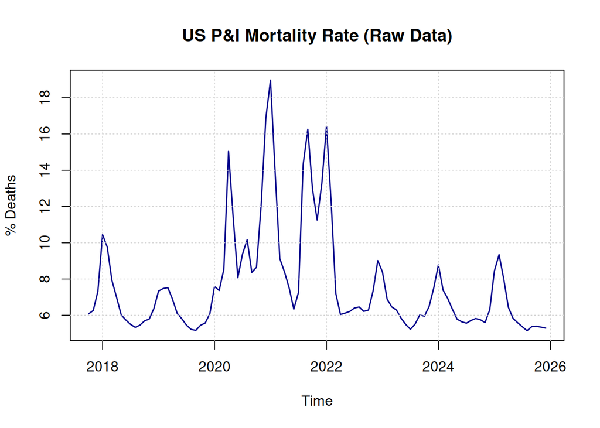

```r
# Plot Raw Data
plot(ts_raw, main="US P&I Mortality Rate (Raw Data)", ylab="% Deaths", col="darkblue", lwd=1.5)
grid()
```

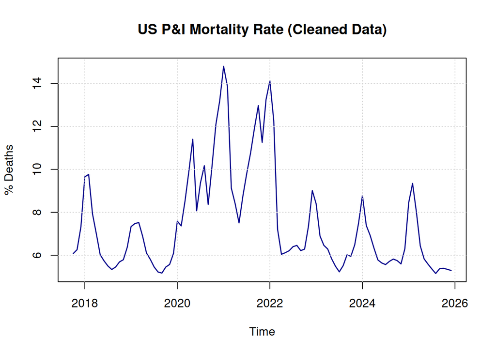

```r
plot(ts_cleaned, main="US P&I Mortality Rate (Cleaned Data)", ylab="% Deaths", col="darkblue", lwd=1.5)
grid()
```

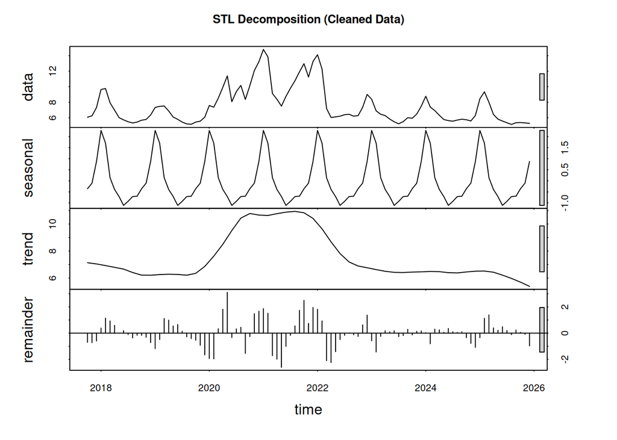

```r
# STL Decomposition (Using Cleaned Data to see clear seasonality)
decomp <- stl(ts_cleaned, s.window="periodic")
plot(decomp, main="STL Decomposition (Cleaned Data)")
```

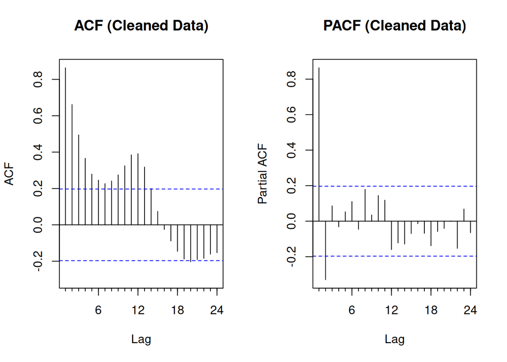

```r
# ACF and PACF
par(mfrow=c(1,2))
Acf(ts_cleaned, main="ACF (Cleaned Data)")
Pacf(ts_cleaned, main="PACF (Cleaned Data)")
```

```r
par(mfrow=c(1,1))
```

## ETS baseline

First model: ETS with automatic error/trend/seasonality selection, fit on the cleaned series, with a 24-month forecast and residual diagnostics.

```r
# We use ETS (Error, Trend, Seasonality).
# model="ZZZ" allows the function to automatically select the best error/trend/season type

# Fit ETS Model
fit_ets <- forecast::ets(ts_cleaned, model="ZZZ")

# Summary of chosen model
print(summary(fit_ets))
```

```
## ETS(M,A,M)
##
## Call:
##  forecast::ets(y = ts_cleaned, model = "ZZZ")
##
##   Smoothing parameters:
##     alpha = 0.9999
##     beta  = 0.0069
##     gamma = 1e-04
##
##   Initial states:
##     l = 6.7712
##     b = 0.0502
##     s = 0.8951 0.8997 0.8954 0.8911 0.9217 0.9839
##            1.0683 1.2046 1.2719 1.0813 0.9631 0.9239
##
##   sigma:  0.1111
##
##      AIC     AICc      BIC
## 428.9658 436.5213 473.0828
##
## Training set error measures:
##                       ME      RMSE       MAE       MPE     MAPE      MASE
## Training set -0.07002914 0.9571876 0.6270374 -1.419412 7.662248 0.3705041
##                   ACF1
## Training set 0.1141287
```

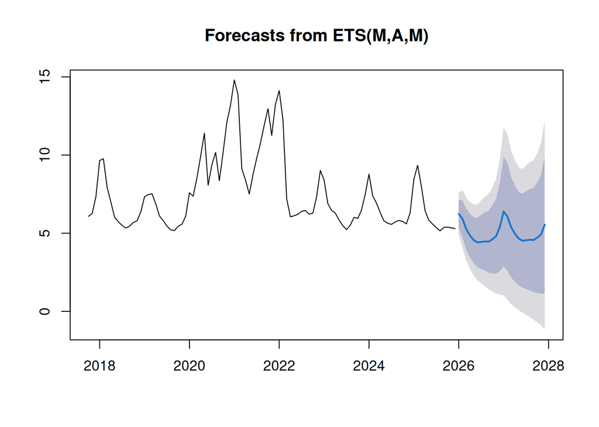

```r
# Plot ETS Forecast
ets_fc <- forecast::forecast(fit_ets, h=24)

plot(ets_fc)
```

```r
test(ets_fc$residuals)
```

```
## Null hypothesis: Residuals are iid noise.
## Test                        Distribution Statistic   p-value
## Ljung-Box Q                Q ~ chisq(20)     16.76    0.6683
## McLeod-Li Q                Q ~ chisq(20)     30.69    0.0594
## Turning points T   (T-64.7)/4.2 ~ N(0,1)        55      0.02 *
## Diff signs S         (S-49)/2.9 ~ N(0,1)        45    0.1659
## Rank P         (P-2425.5)/165.4 ~ N(0,1)      2312    0.4926
```

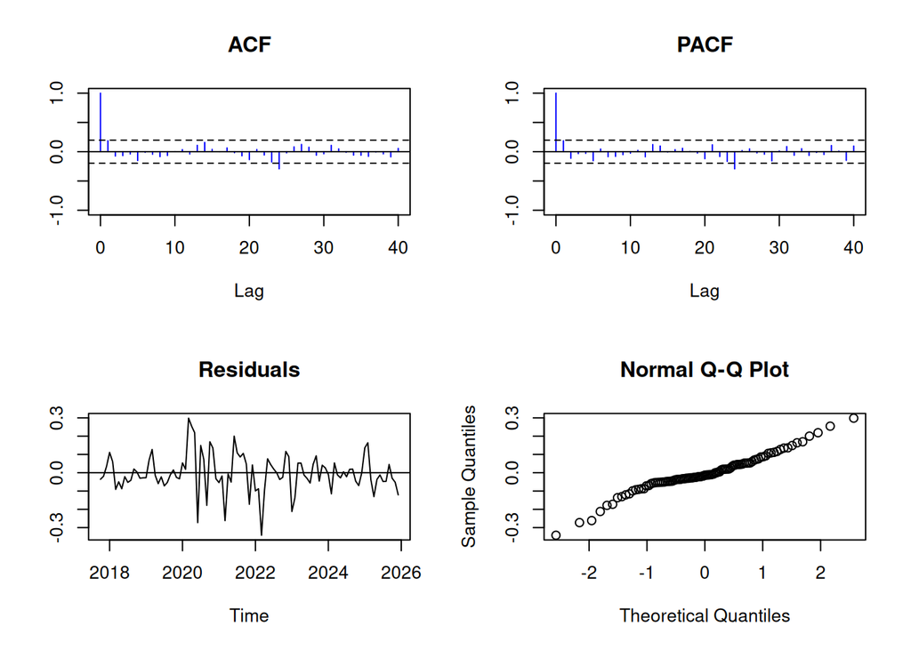

## Checking stationarity

Before ARIMA, I ran ADF tests on the level, the seasonally differenced series, and the doubly differenced series to see how much differencing the data needs.

```r
# 1. Test on Level Data
print("--- ADF Test: Level ---")
```

```
## [1] "--- ADF Test: Level ---"
```

```r
print(aTSA::adf.test(ts_cleaned))
```

```
## Augmented Dickey-Fuller Test
## alternative: stationary
##
## Type 1: no drift no trend
##      lag    ADF p.value
## [1,]   0 -0.803   0.391
## [2,]   1 -1.026   0.310
## [3,]   2 -0.926   0.346
## [4,]   3 -1.067   0.295
## Type 2: with drift no trend
##      lag   ADF p.value
## [1,]   0 -2.54  0.1188
## [2,]   1 -3.50  0.0103
## [3,]   2 -2.91  0.0495
## [4,]   3 -2.87  0.0555
## Type 3: with drift and trend
##      lag   ADF p.value
## [1,]   0 -2.66  0.3015
## [2,]   1 -3.61  0.0361
## [3,]   2 -3.00  0.1607
## [4,]   3 -2.91  0.1998
## ----
## Note: in fact, p.value = 0.01 means p.value <= 0.01
## $type1
##      lag        ADF   p.value
## [1,]   0 -0.8034741 0.3905352
## [2,]   1 -1.0262195 0.3102956
## [3,]   2 -0.9258934 0.3464361
## [4,]   3 -1.0674007 0.2954608
##
## $type2
##      lag       ADF    p.value
## [1,]   0 -2.541870 0.11883178
## [2,]   1 -3.497098 0.01029448
## [3,]   2 -2.906392 0.04952136
## [4,]   3 -2.867271 0.05545830
##
## $type3
##      lag       ADF    p.value
## [1,]   0 -2.656604 0.30154692
## [2,]   1 -3.607885 0.03612138
## [3,]   2 -3.002233 0.16070374
## [4,]   3 -2.906207 0.19983410
```

```r
# 2. Test on Seasonal Difference (D=1)
ts_diff <- diff(ts_cleaned, lag=12)
print("--- ADF Test: Seasonal Difference (D=1) ---")
```

```
## [1] "--- ADF Test: Seasonal Difference (D=1) ---"
```

```r
print(aTSA::adf.test(ts_diff))
```

```
## Augmented Dickey-Fuller Test
## alternative: stationary
##
## Type 1: no drift no trend
##      lag   ADF p.value
## [1,]   0 -2.66  0.0100
## [2,]   1 -2.93  0.0100
## [3,]   2 -2.50  0.0143
## [4,]   3 -2.54  0.0125
## Type 2: with drift no trend
##      lag   ADF p.value
## [1,]   0 -2.65  0.0914
## [2,]   1 -2.91  0.0499
## [3,]   2 -2.49  0.1409
## [4,]   3 -2.53  0.1255
## Type 3: with drift and trend
##      lag   ADF p.value
## [1,]   0 -2.72   0.275
## [2,]   1 -3.00   0.162
## [3,]   2 -2.60   0.324
## [4,]   3 -2.71   0.280
## ----
## Note: in fact, p.value = 0.01 means p.value <= 0.01
## $type1
##      lag       ADF    p.value
## [1,]   0 -2.660852 0.01000000
## [2,]   1 -2.925013 0.01000000
## [3,]   2 -2.501546 0.01430213
## [4,]   3 -2.544426 0.01252926
##
## $type2
##      lag       ADF    p.value
## [1,]   0 -2.647268 0.09137071
## [2,]   1 -2.909390 0.04991106
## [3,]   2 -2.486887 0.14090899
## [4,]   3 -2.526822 0.12548383
##
## $type3
##      lag       ADF   p.value
## [1,]   0 -2.724249 0.2752020
## [2,]   1 -3.004827 0.1619747
## [3,]   2 -2.604446 0.3235489
## [4,]   3 -2.712112 0.2801000
```

```r
# 3. Test on Double Difference (D=1, d=1)
# Often required if seasonal differencing alone doesn't remove the trend
ts_doubly_diff <- diff(ts_diff, lag=1)
print("--- ADF Test: Seasonal + First Difference (D=1, d=1) ---")
```

```
## [1] "--- ADF Test: Seasonal + First Difference (D=1, d=1) ---"
```

```r
print(aTSA::adf.test(ts_doubly_diff))
```

```
## Augmented Dickey-Fuller Test
## alternative: stationary
##
## Type 1: no drift no trend
##      lag   ADF p.value
## [1,]   0 -8.65    0.01
## [2,]   1 -7.48    0.01
## [3,]   2 -5.90    0.01
## [4,]   3 -5.33    0.01
## Type 2: with drift no trend
##      lag   ADF p.value
## [1,]   0 -8.59    0.01
## [2,]   1 -7.43    0.01
## [3,]   2 -5.86    0.01
## [4,]   3 -5.30    0.01
## Type 3: with drift and trend
##      lag   ADF p.value
## [1,]   0 -8.54    0.01
## [2,]   1 -7.39    0.01
## [3,]   2 -5.84    0.01
## [4,]   3 -5.28    0.01
## ----
## Note: in fact, p.value = 0.01 means p.value <= 0.01
## $type1
##      lag       ADF p.value
## [1,]   0 -8.645996    0.01
## [2,]   1 -7.476852    0.01
## [3,]   2 -5.899900    0.01
## [4,]   3 -5.331257    0.01
##
## $type2
##      lag       ADF p.value
## [1,]   0 -8.594412    0.01
## [2,]   1 -7.431110    0.01
## [3,]   2 -5.863559    0.01
## [4,]   3 -5.297977    0.01
##
## $type3
##      lag       ADF p.value
## [1,]   0 -8.544893    0.01
## [2,]   1 -7.390294    0.01
## [3,]   2 -5.840880    0.01
## [4,]   3 -5.283964    0.01
```

## ARIMA bake-off

Three candidates, all fit with `auto.arima`: one on the raw data, one on the cleaned data, and one on the cleaned data with a log transform. The trace output is hidden to keep the document readable.

```r
# Model 1: ARIMA on Raw Data
fit_raw <- auto.arima(ts_raw, seasonal=TRUE, stepwise=FALSE, approximation=FALSE, trace=TRUE)

# Model 2: ARIMA on Cleaned Data (No Transformation)
fit_clean <- auto.arima(ts_cleaned, seasonal=TRUE, stepwise=FALSE, approximation=FALSE, trace=TRUE)

# Model 3: ARIMA on Cleaned Data + Log Transformation
fit_log_clean <- auto.arima(ts_cleaned, seasonal=TRUE, lambda=0, approximation=FALSE, trace=TRUE)
```

```r
# Function to extract metrics
get_accuracy <- function(model, name) {
  acc <- accuracy(model)
  return(data.frame(
    Model = name,
    AICc = round(model$aicc, 2),
    RMSE = round(acc[2], 4),
    MAPE = round(acc[5], 4)
  ))
}

# Combine into a table
comparison_table <- rbind(
  get_accuracy(fit_raw, "ARIMA (Raw Data)"),
  get_accuracy(fit_clean, "ARIMA (Cleaned Data)"),
  get_accuracy(fit_log_clean, "ARIMA (Cleaned + Log)")
)

kable(comparison_table, caption = "Model Accuracy Comparison")
```

Model Accuracy Comparison

| Model | AICc | RMSE | MAPE |
| --- | --- | --- | --- |
| ARIMA (Raw Data) | 363.24 | 1.4169 | 9.9286 |
| ARIMA (Cleaned Data) | 304.87 | 1.0744 | 9.1604 |
| ARIMA (Cleaned + Log) | -127.60 | 1.1057 | 8.6107 |

Residual diagnostics for all three fits:

```r
test(fit_raw$residuals)
```

```
## Null hypothesis: Residuals are iid noise.
## Test                        Distribution Statistic   p-value
## Ljung-Box Q                Q ~ chisq(20)     21.66    0.3593
## McLeod-Li Q                Q ~ chisq(20)     47.23     5e-04 *
## Turning points T   (T-64.7)/4.2 ~ N(0,1)        63    0.6884
## Diff signs S         (S-49)/2.9 ~ N(0,1)        54    0.0833
## Rank P         (P-2425.5)/165.4 ~ N(0,1)      2317    0.5118
```

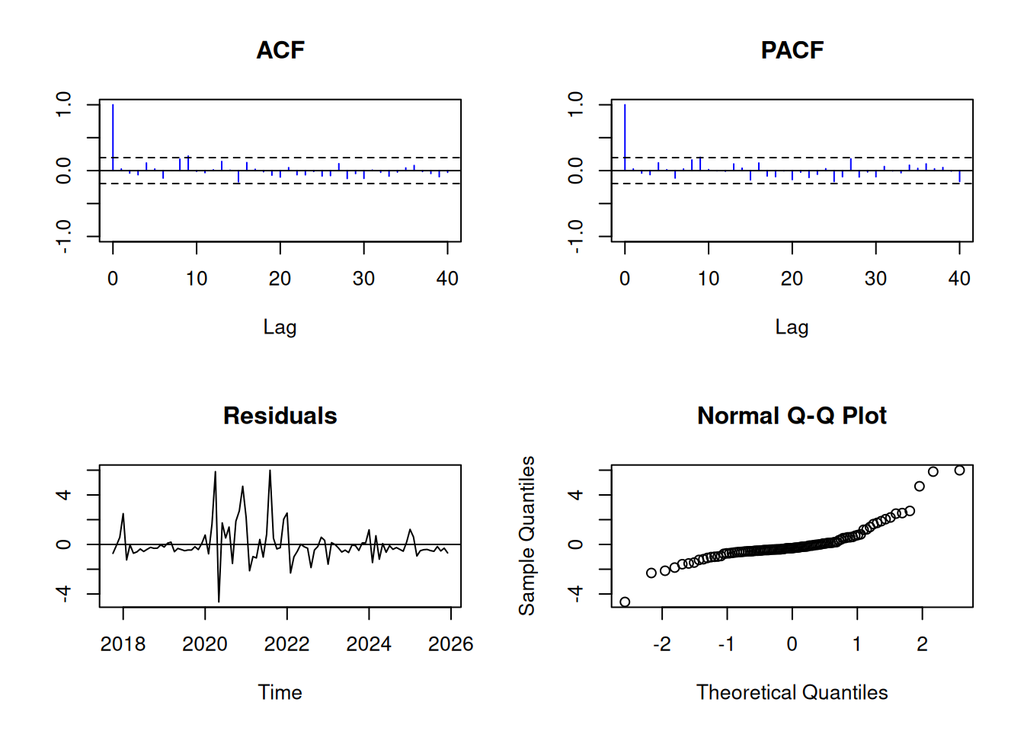

```r
test(fit_clean$residuals)
```

```
## Null hypothesis: Residuals are iid noise.
## Test                        Distribution Statistic   p-value
## Ljung-Box Q                Q ~ chisq(20)     15.61    0.7405
## McLeod-Li Q                Q ~ chisq(20)     58.39         0 *
## Turning points T   (T-64.7)/4.2 ~ N(0,1)        63    0.6884
## Diff signs S         (S-49)/2.9 ~ N(0,1)        53    0.1659
## Rank P         (P-2425.5)/165.4 ~ N(0,1)      2283    0.3889
```

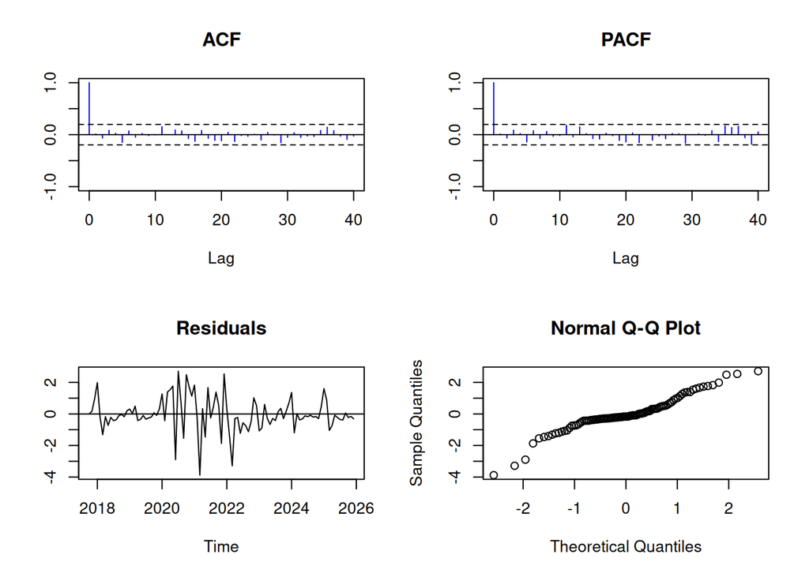

```r
test(fit_log_clean$residuals)
```

```
## Null hypothesis: Residuals are iid noise.
## Test                        Distribution Statistic   p-value
## Ljung-Box Q                Q ~ chisq(20)     18.99    0.5226
## McLeod-Li Q                Q ~ chisq(20)     53.07     1e-04 *
## Turning points T   (T-64.7)/4.2 ~ N(0,1)        65    0.9361
## Diff signs S         (S-49)/2.9 ~ N(0,1)        52    0.2987
## Rank P         (P-2425.5)/165.4 ~ N(0,1)      2333     0.576
```

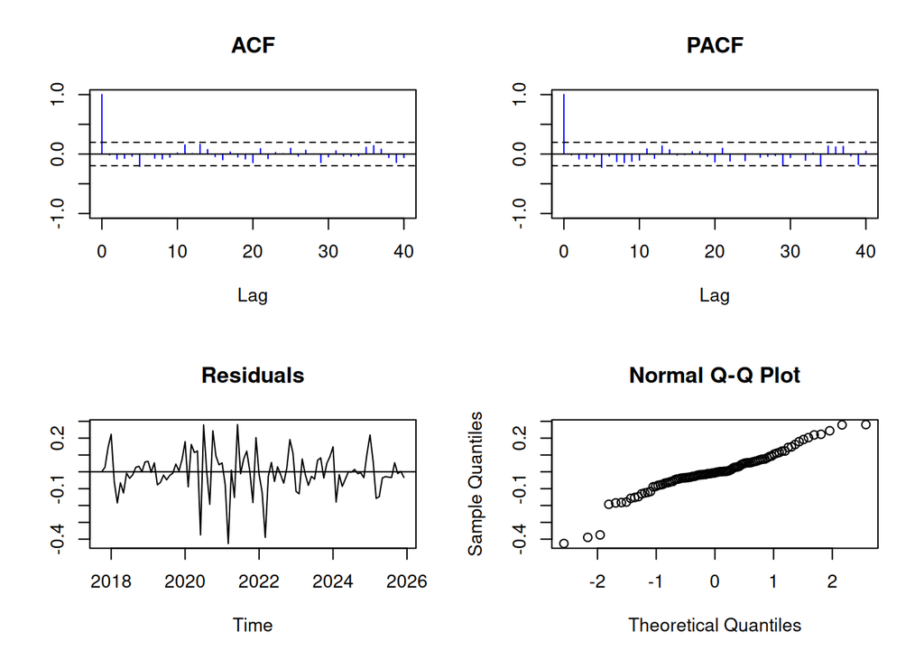

The log-transformed model on the cleaned series became the final forecasting model. Below are all three forecasts for comparison, then the chosen 24-month forecast with its values tabulated.

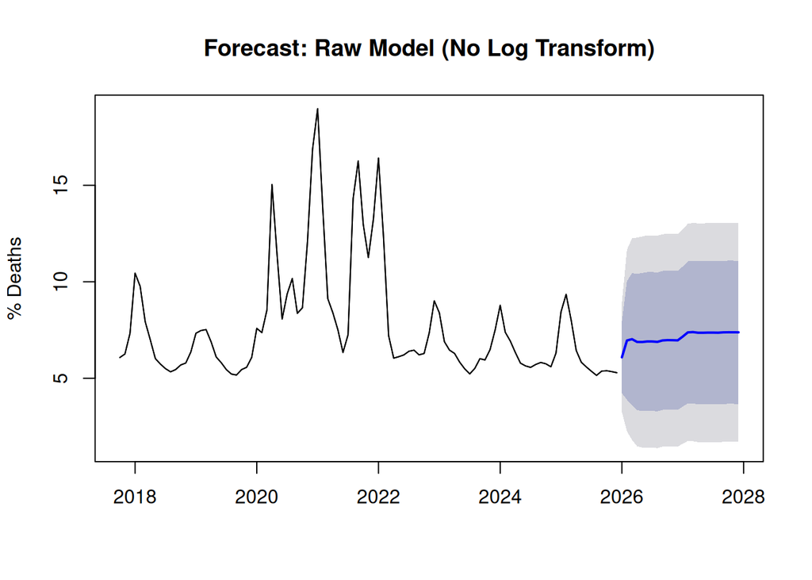

```r
# Generate Forecasts
fc_raw <- forecast::forecast(fit_raw, h=24)
fc_clean <- forecast::forecast(fit_clean, h=24)
fc_log_clean  <- forecast::forecast(fit_log_clean, h=24, biasadj=TRUE)

plot(fc_raw, main="Forecast: Raw Model (No Log Transform)", ylab="% Deaths", fcol="blue")
lines(ts_raw, col="black")
```

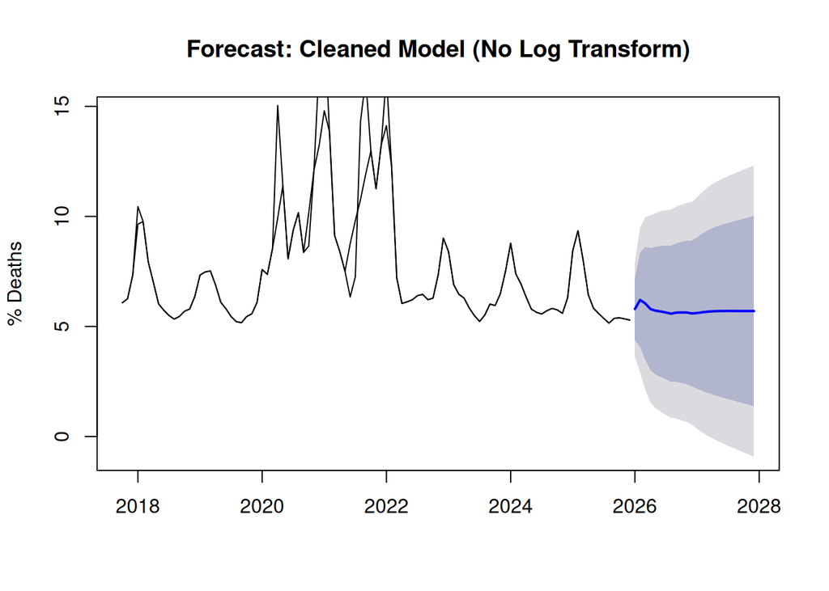

```r
# PLOT 1: Cleaned Data Model
plot(fc_clean, main="Forecast: Cleaned Model (No Log Transform)", ylab="% Deaths", fcol="blue")
lines(ts_raw, col="black")
```

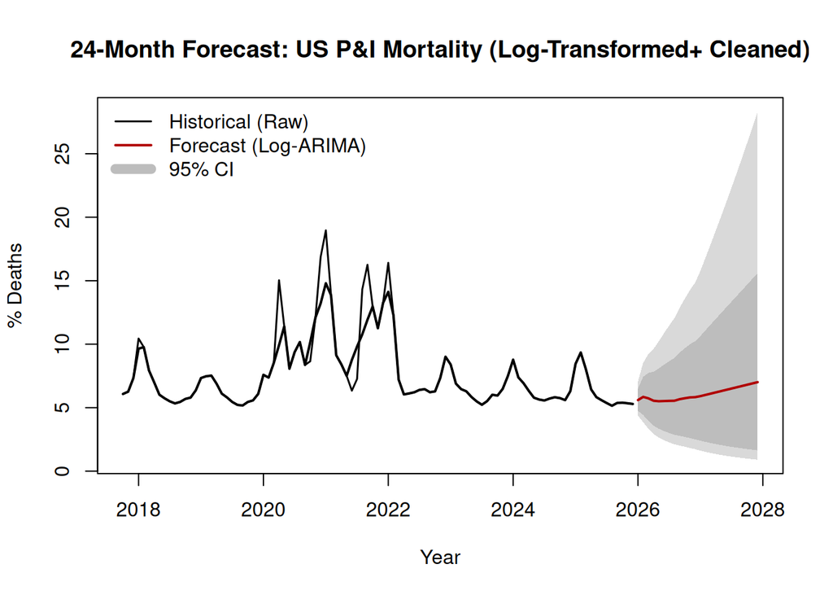

```r
plot(fc_log_clean,
     main="24-Month Forecast: US P&I Mortality (Log-Transformed+ Cleaned)",
     ylab="% Deaths",
     xlab="Year",
     fcol="#b00000",       # Dark Red
     flty=1, lwd=2,
     shadecols=c("#d9d9d9", "#bdbdbd")
     )        # Focus on realistic range

# Overlay Historical Data
lines(ts_raw, col="black", lwd=1.5)

legend("topleft",
       legend=c("Historical (Raw)", "Forecast (Log-ARIMA)", "95% CI"),
       col=c("black", "#b00000", "#bdbdbd"),
       lty=c(1, 1, 1), lwd=c(1.5, 2, 8), bty="n")
```

```r
# Extract forecast values into a readable dataframe
fc_values <- data.frame(
  Date = seq(from = max(monthly_data$MonthDate) %m+% months(1), by = "month", length.out = 24),
  Forecast = round(fc_log_clean$mean, 2),
  Lower_95 = round(fc_log_clean$lower[,"95%"], 2),
  Upper_95 = round(fc_log_clean$upper[,"95%"], 2)
)

kable(fc_values, caption = "24-Month Forecast Values (Log-ARIMA)")
```

24-Month Forecast Values (Log-ARIMA)

| Date | Forecast | Lower_95 | Upper_95 |
| --- | --- | --- | --- |
| 2026-01-01 | 5.60 | 4.37 | 7.07 |
| 2026-02-01 | 5.85 | 3.85 | 8.53 |
| 2026-03-01 | 5.73 | 3.34 | 9.22 |
| 2026-04-01 | 5.54 | 2.91 | 9.63 |
| 2026-05-01 | 5.51 | 2.64 | 10.22 |
| 2026-06-01 | 5.52 | 2.44 | 10.86 |
| 2026-07-01 | 5.54 | 2.27 | 11.47 |
| 2026-08-01 | 5.54 | 2.11 | 12.05 |
| 2026-09-01 | 5.67 | 2.02 | 12.87 |
| 2026-10-01 | 5.74 | 1.92 | 13.58 |
| 2026-11-01 | 5.81 | 1.83 | 14.27 |
| 2026-12-01 | 5.83 | 1.73 | 14.85 |
| 2027-01-01 | 5.91 | 1.62 | 15.78 |
| 2027-02-01 | 6.01 | 1.52 | 16.84 |
| 2027-03-01 | 6.11 | 1.43 | 17.91 |
| 2027-04-01 | 6.21 | 1.35 | 18.99 |
| 2027-05-01 | 6.31 | 1.27 | 20.09 |
| 2027-06-01 | 6.41 | 1.20 | 21.21 |
| 2027-07-01 | 6.51 | 1.14 | 22.34 |
| 2027-08-01 | 6.61 | 1.09 | 23.50 |
| 2027-09-01 | 6.71 | 1.04 | 24.67 |
| 2027-10-01 | 6.81 | 0.99 | 25.87 |
| 2027-11-01 | 6.91 | 0.94 | 27.09 |
| 2027-12-01 | 7.01 | 0.90 | 28.33 |

## Hybrid ARIMA plus GARCH

The ARIMA mean forecast assumes constant variance, but mortality spikes cluster. So I fit a GARCH(1,1) with Student-t errors on the raw ARIMA residuals, deliberately using the raw fit’s residuals to keep the real spikes in the volatility estimate. The conditional volatility plot shows when uncertainty was highest.

```r
library(rugarch)
# 1. Extract Residuals from the best ARIMA fit
best_residuals <- residuals(fit_raw) # Using Raw ARIMA residuals to capture the real spikes

# 2. Define GARCH(1,1) Specification
garch_spec <- ugarchspec(
  variance.model = list(model = "sGARCH", garchOrder = c(1, 1)),
  mean.model = list(armaOrder = c(0, 0), include.mean = FALSE),
  distribution.model = "std"
)

# 3. Fit GARCH
garch_fit <- ugarchfit(spec = garch_spec, data = best_residuals)

# 4. Diagnostics
print(garch_fit)
```

```
##
## *---------------------------------*
## *          GARCH Model Fit        *
## *---------------------------------*
##
## Conditional Variance Dynamics
## -----------------------------------
## GARCH Model  : sGARCH(1,1)
## Mean Model   : ARFIMA(0,0,0)
## Distribution : std
##
## Optimal Parameters
## ------------------------------------
##         Estimate  Std. Error  t value Pr(>|t|)
## omega    0.12151     0.10091   1.2041 0.228543
## alpha1   0.35169     0.24499   1.4355 0.151140
## beta1    0.64731     0.14834   4.3637 0.000013
## shape    3.19291     0.90405   3.5318 0.000413
##
## Robust Standard Errors:
##         Estimate  Std. Error  t value Pr(>|t|)
## omega    0.12151     0.11448   1.0614 0.288507
## alpha1   0.35169     0.32637   1.0776 0.281214
## beta1    0.64731     0.21312   3.0373 0.002387
## shape    3.19291     0.78369   4.0742 0.000046
##
## LogLikelihood : -139.523
##
## Information Criteria
## ------------------------------------
##
## Akaike       2.8995
## Bayes        3.0043
## Shibata      2.8964
## Hannan-Quinn 2.9419
##
## Weighted Ljung-Box Test on Standardized Residuals
## ------------------------------------
##                         statistic p-value
## Lag[1]                      1.215  0.2704
```

[output cut: 37 more lines]

```
## Negative Sign Bias  0.1198 0.90486
## Positive Sign Bias  0.1546 0.87750
## Joint Effect        9.8625 0.01977  **
##
##
## Adjusted Pearson Goodness-of-Fit Test:
## ------------------------------------
##   group statistic p-value(g-1)
## 1    20     45.85    0.0005207
## 2    30     47.97    0.0148046
## 3    40     58.17    0.0247384
## 4    50     79.28    0.0039810
##
##
## Elapsed time : 0.06508613
```

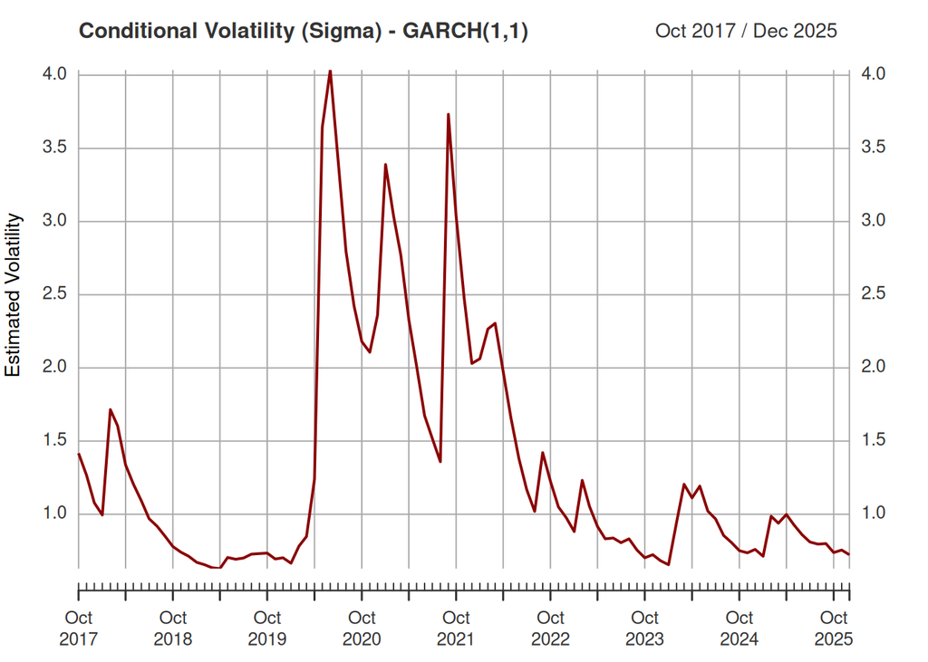

```r
# Plot Conditional Volatility (Sigma)
volatility <- sigma(garch_fit)
plot(volatility, type="l", col="darkred",
     main="Conditional Volatility (Sigma) - GARCH(1,1)",
     ylab="Estimated Volatility", xlab="Time")
grid()
```

```r
# Extract Standardized Residuals
std_resid <- residuals(garch_fit, standardize=TRUE)

# Diagnostic Tests (Ljung-Box, etc.)
test(as.numeric(std_resid))
```

```
## Null hypothesis: Residuals are iid noise.
## Test                        Distribution Statistic   p-value
## Ljung-Box Q                Q ~ chisq(20)     15.72     0.734
## McLeod-Li Q                Q ~ chisq(20)     24.31    0.2289
## Turning points T   (T-64.7)/4.2 ~ N(0,1)        63    0.6884
## Diff signs S         (S-49)/2.9 ~ N(0,1)        52    0.2987
## Rank P         (P-2425.5)/165.4 ~ N(0,1)      2240     0.262
```

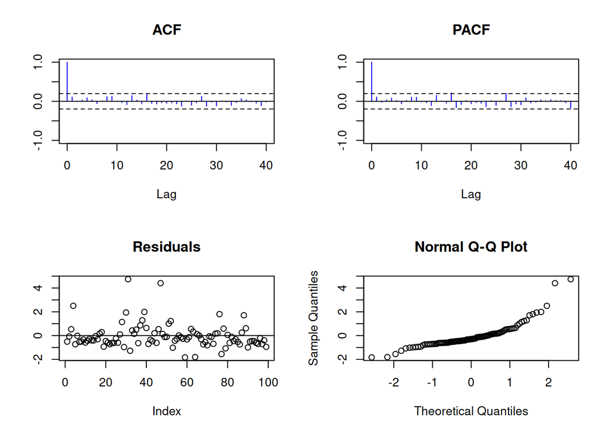